# Logistic Regression in R

## 1 Logistics Regression Model

- Remember from the lecture that we are fitting a regression model with a binary outcome.
- As such, the model is as follows:

$$\begin{eqnarray*}
\log \Big(\frac{\hat{p}}{1 - \hat{p}} \Big) & = & a + b_{1}x_1 + \ldots + b_{q}x_{q}
\end{eqnarray*}$$

- The left hand side of this model is the logarithm of the odds of success. It is a monotonously increasing function, which means when $b_1$ is positive, if $x_1$ increases, the odds of success increases. Try plot this in Desmos!
- Thereby, the probability of success of $\hat{p}$ can be written as follows:

$$\begin{eqnarray*}
\hat{p} & = & \frac{\exp(a + b_{1}x_1 + \ldots + b_{q}x_{q})}{1 + \exp(a + b_{1}x_1 + \ldots + b_{q}x_{q})}
\end{eqnarray*}$$

- The above means once we estimate the coefficients of the model, we can estimate the probability of success of the outcome of interest.

## 2 Import data

- Let’s revisit Alzheimer’s data set, and consider the task of building a logistic regression model with diagnosis as its response variable and variables age, education, hippocampus volume, and female as its predictors.

```r
library(tidyverse)

alzheimer_data <- read_csv("https://raw.githubusercontent.com/COSMOS-DataScience/slides/main/data/alzheimer_data.csv")
```

## 3 Data pre-processing

### 3.1 Clean up the columns

- Running a logistic regression model in R is pretty straightforward. Before we do that, let’s use `select()` function to select the interested variable (diagnosis, age, education, lhippo, rhippo, and female).

```r
alzheimer_data <- alzheimer_data %>%
  select(diagnosis, age, educ, female, lhippo,rhippo)

glimpse(alzheimer_data)
```

```
Rows: 2,700
Columns: 6
$ diagnosis <dbl> 0, 0, 0, 0, 1, 0, 0, 2, 0, 2, 0, 0, 0, 1, 0, 1, 2, 2, 2, 1, …
$ age       <dbl> 74, 56, 77, 74, 75, 72, 64, 78, 73, 81, 66, 65, 66, 73, 78, …
$ educ      <dbl> 12, 16, 18, 20, 14, 16, 16, 17, 18, 13, 16, 16, 17, 20, 13, …
$ female    <dbl> 0, 1, 1, 1, 0, 1, 1, 0, 1, 0, 1, 1, 0, 1, 1, 1, 0, 0, 1, 1, …
$ lhippo    <dbl> 2.2900, 3.2606, 2.6990, 3.0600, 2.9342, 3.2100, 3.6800, 1.73…
$ rhippo    <dbl> 2.9200, 3.3321, 2.5028, 3.0000, 3.2890, 3.0600, 3.8200, 2.30…
```

### 3.2 Data wrangling

- Let’s begin by transforming the response to a new feature with two categories: no symptoms (0) versus mild or strong symptoms (1).
- It is noticeable that female is a numeric variable. As such, we should make sure R recognizes that feature as a factor variable.
- Create a new variable `hippo` as the sum of left hippocampus volume (lhippo) and right hippocampus volume (rhippo).

```r
alzheimer_data <- alzheimer_data %>%
  mutate(diag = ifelse(diagnosis %in% c(1, 2), "1", "0"),
         diag = as.factor(diag),
         female = as.factor(female),
         hippo = lhippo + rhippo)
```

### 3.3 Data visualization

Let’s explore these relationships using visualizations.

- What is the relationship between diagnosis v.s. hippocampus?
- What is the relationship between diagnosis v.s. gender?
- What is the relationship between diagnosis v.s. education years?

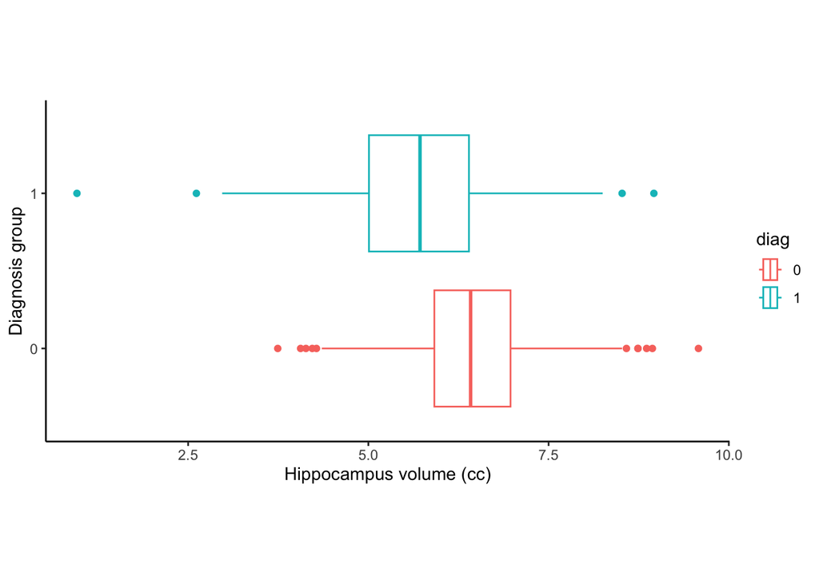

```r
alzheimer_data %>%
  ggplot(aes(x = hippo, y = diag, color = diag))+
  geom_boxplot()+
  theme_classic() +
  labs(x = 'Hippocampus volume (cc)', y = 'Diagnosis group')+
  theme(aspect.ratio = 0.5)
```

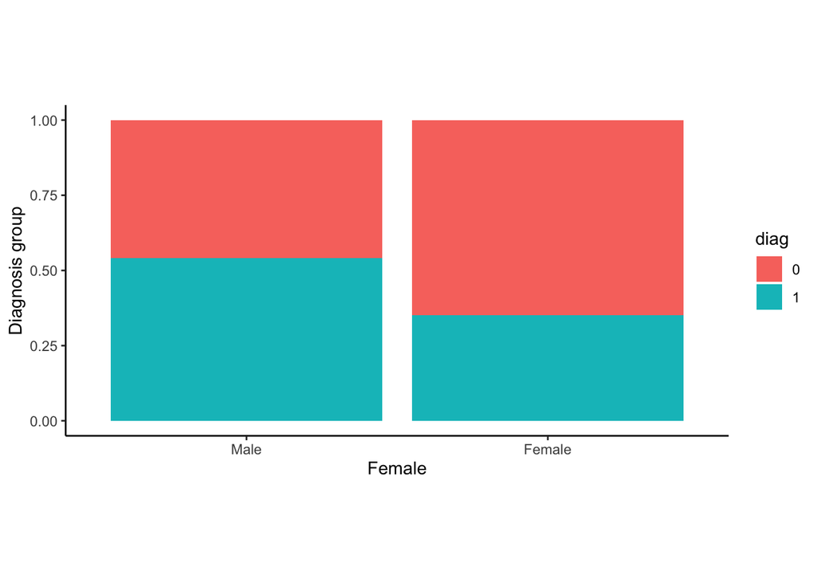

```r
alzheimer_data %>%
  mutate(female = fct_recode(female, Male="0",Female="1")) %>%
  ggplot(aes(x = female, fill = diag))+
  geom_bar(position = 'fill') +
  theme_classic() +
  labs(x = 'Female', y = 'Diagnosis group')+
  theme(aspect.ratio = 0.5)
```

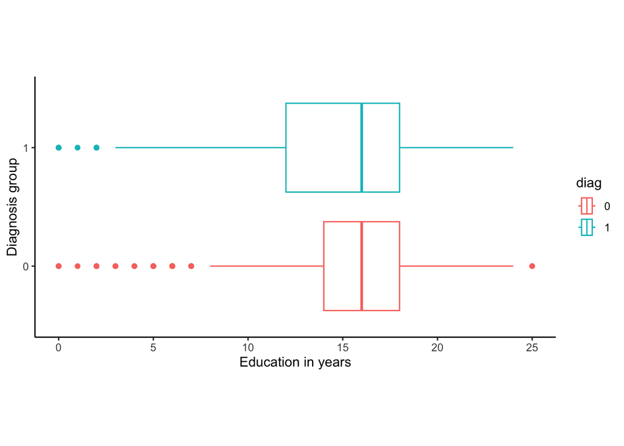

```r
alzheimer_data %>%
  ggplot(aes(x = educ, y = diag, color = diag))+
  geom_boxplot()+
  theme_classic() +
  labs(x = 'Education in years', y = 'Diagnosis group')+
  theme(aspect.ratio = 0.5)
```

## 4 Model fitting

We will use `glm()` function to fit logistics regression.

```r
logistic_model <- glm(
  diag ~ educ + age + female + hippo,
  family = "binomial",
  data = alzheimer_data)

summary(logistic_model)
```

```
Call:
glm(formula = diag ~ educ + age + female + hippo, family = "binomial",
    data = alzheimer_data)

Coefficients:
             Estimate Std. Error z value Pr(>|z|)
(Intercept)  6.417112   0.595993  10.767  < 2e-16 ***
educ        -0.053793   0.013290  -4.048 5.17e-05 ***
age          0.017096   0.004262   4.011 6.04e-05 ***
female1     -1.347349   0.097097 -13.876  < 2e-16 ***
hippo       -1.037441   0.059413 -17.462  < 2e-16 ***
---
Signif. codes:  0 '***' 0.001 '**' 0.01 '*' 0.05 '.' 0.1 ' ' 1

(Dispersion parameter for binomial family taken to be 1)

    Null deviance: 3692.7  on 2699  degrees of freedom
Residual deviance: 3019.4  on 2695  degrees of freedom
AIC: 3029.4

Number of Fisher Scoring iterations: 4
```

## 5 Model interpretation:

If we plug in the estimated values from the model above, we have

$$\begin{eqnarray*}
\log \Big(\frac{\hat{p}}{1- \hat{p}} \Big) & = & 6.42 -0.05\,x_{\text{educ}} + 0.02\,x_{\text{age}} -1.35\,x_{\text{female}} -1.04\,x_{\text{hippo}}
\end{eqnarray*}$$

Let’s say we want to estimate the probability of having symptoms for Alzheimer’s disease for a person with specific characteristics.

```r
newx_df <- data.frame(
  age    = 40,
  female = factor(0, levels = levels(alzheimer_data$female)),
  educ   = 10,
  hippo  = 6
)
pred_prob = predict(logistic_model, newdata = newx_df, type = "response") %>%
  round(digits = 2)
```

## 6 Format the output to a publication-ready table

```r
library(gtsummary) # for tbl_regression() function

logistic_model %>%
  tbl_regression(
    estimate_fun = function(x){style_number(x, digits = 3)},
    exponentiate = TRUE)
```

| **Characteristic** | **OR** | **95% CI** | **p-value** |
| --- | --- | --- | --- |
| educ | 0.948 | 0.923, 0.973 | <0.001 |
| age | 1.017 | 1.009, 1.026 | <0.001 |
| female |  |  |  |
| 0 | — | — |  |
| 1 | 0.260 | 0.215, 0.314 | <0.001 |
| hippo | 0.354 | 0.315, 0.398 | <0.001 |

Abbreviations: CI = Confidence Interval, OR = Odds Ratio

## 7 Model Evaluation:

To split the data into training and validation sets using the rsample package in R, you can use the `initial_split()` function. Here’s an example of how you can split the data:

```r
library(rsample)

set.seed(0)
data_split <- initial_split(alzheimer_data, prop = 0.7)

train_data <- training(data_split)
test_data <- testing(data_split)
```

#### 7.0.1 Fit the model with train data

As we saw, next step after splitting the data into train and test would be training the model using training data:

```r
logistic_model2 <- glm(diag ~ educ + age + hippo + female, family=binomial, data=train_data)
summary(logistic_model2)
```

```
Call:
glm(formula = diag ~ educ + age + hippo + female, family = binomial,
    data = train_data)

Coefficients:
             Estimate Std. Error z value Pr(>|z|)
(Intercept)  6.595232   0.722410   9.129  < 2e-16 ***
educ        -0.064738   0.015687  -4.127 3.68e-05 ***
age          0.016344   0.005117   3.194   0.0014 **
hippo       -1.032922   0.071457 -14.455  < 2e-16 ***
female1     -1.333364   0.116105 -11.484  < 2e-16 ***
---
Signif. codes:  0 '***' 0.001 '**' 0.01 '*' 0.05 '.' 0.1 ' ' 1

(Dispersion parameter for binomial family taken to be 1)

    Null deviance: 2578.5  on 1888  degrees of freedom
Residual deviance: 2112.9  on 1884  degrees of freedom
AIC: 2122.9

Number of Fisher Scoring iterations: 4
```

```r
logistic_model2 %>%
  tbl_regression(estimate_fun = function(x) style_number(x, digits = 3), exponentiate = TRUE)
```

| **Characteristic** | **OR** | **95% CI** | **p-value** |
| --- | --- | --- | --- |
| educ | 0.937 | 0.909, 0.966 | <0.001 |
| age | 1.016 | 1.006, 1.027 | 0.001 |
| hippo | 0.356 | 0.309, 0.409 | <0.001 |
| female |  |  |  |
| 0 | — | — |  |
| 1 | 0.264 | 0.209, 0.330 | <0.001 |

Abbreviations: CI = Confidence Interval, OR = Odds Ratio

#### 7.0.2 Validate on test data

Followed, by testing it via the validation set. This means to calculate the probability of success for each subject in the test set:

```r
pred_prob <- logistic_model2 %>%
  predict(test_data,type="response")
```

- We are now ready to calculate the accuracy of our trained model. To accomplish this, we translate all probabilities of success above to 0.5 to a 1 and otherwise to a 0, followed by tracking the number of correct predictions (1’s correctly predicted as 1’s and 0’s correctly predicted as 0’s).

```r
predicted.classes <- ifelse(pred_prob > 0.5, "1", "0")
acc = mean(predicted.classes == test_data$diag) %>%
  round(2)

print(paste("This model yields a", acc, "accuracy rate!"))
```

```
[1] "This model yields a 0.71 accuracy rate!"
```

## 8 Let’s practice

Try to build a logistics model to predict AD (diagnosis = 2) or not AD (diagnosis = 1 or 0). In other words, transforming the response to a new feature with two categories: no or mild symptoms(0) versus strong symptoms (1).

Note: give the data/model a new name!

Question: What is your accuracy on validation set? Is it higher than chance?

```r
alzheimer_data <- read_csv("https://raw.githubusercontent.com/COSMOS-DataScience/slides/main/data/alzheimer_data.csv")
AD_data <- alzheimer_data %>%
  mutate(diag = ifelse(diagnosis %in% c(2), "1", "0"),
         diag = as.factor(diag),
         female = as.factor(female),
         hippo = lhippo + rhippo)

# data splitting
set.seed(0)
data_split <- initial_split(AD_data, prop = 0.7)

train_data <- training(data_split)
test_data <- testing(data_split)

# model fit
logistic_AD <- glm(diag ~ educ + age + hippo + female, family=binomial, data=train_data)
summary(logistic_AD)
```

```
Call:
glm(formula = diag ~ educ + age + hippo + female, family = binomial,
    data = train_data)

Coefficients:
              Estimate Std. Error z value Pr(>|z|)
(Intercept)  4.8440109  0.7767975   6.236 4.49e-10 ***
educ        -0.0482131  0.0170757  -2.823  0.00475 **
age         -0.0004922  0.0060436  -0.081  0.93509
hippo       -0.8407063  0.0737020 -11.407  < 2e-16 ***
female1     -0.9188226  0.1287350  -7.137 9.52e-13 ***
---
Signif. codes:  0 '***' 0.001 '**' 0.01 '*' 0.05 '.' 0.1 ' ' 1

(Dispersion parameter for binomial family taken to be 1)

    Null deviance: 1874.3  on 1888  degrees of freedom
Residual deviance: 1663.3  on 1884  degrees of freedom
AIC: 1673.3

Number of Fisher Scoring iterations: 4
```

```r
# prediction
pred_prob <- logistic_AD %>%
  predict(test_data,type="response")

predicted.classes <- ifelse(pred_prob > 0.5, "1", "0")
acc = mean(predicted.classes == test_data$diag) %>%
  round(2)

print(paste("This model yields a", acc, "accuracy rate!"))
```

```
[1] "This model yields a 0.8 accuracy rate!"
```

```r
# chance level?
chance1 = mean(test_data$diag == sample(test_data$diag, size = nrow(test_data), replace = TRUE)) %>%
  round(2)
chance2 = max(table(test_data$diag))/nrow(test_data) %>%
  round(2)
```